# writeup

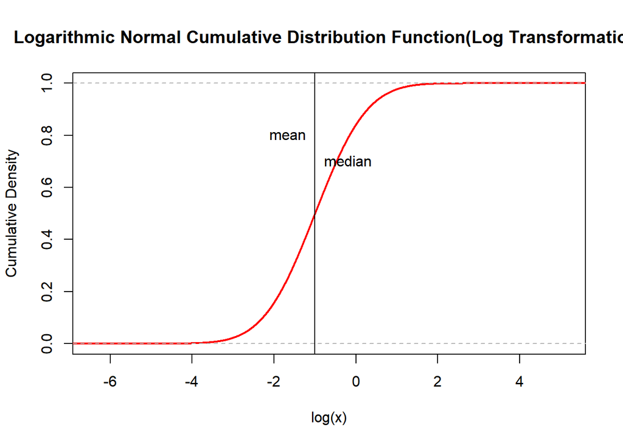

```r
# Cumulative distribution function
set.seed(4)
x = rlnorm(1e6, mean = -1, sd = 1)
y = log(x)
plot(ecdf(y), main = "Logarithmic Normal Cumulative Distribution Function(Log Transformation)", xlab = "log(x)", ylab = "Cumulative Density", ylim = c(0, 1), col = "red", lwd = 2)
abline(v = mean(y))
text(x = mean(y), y = 0.8, "mean", pos = 2)
abline(v = median(y))
text(x = median(y), y = 0.7, "median", pos = 4)
```

Generate 1000 samples of size 100. For each sample, calculate the geometric and arithmetic mean. Generate a scatter plot of the geometic and arithmetic sample means. Add the line of identify as a reference line.

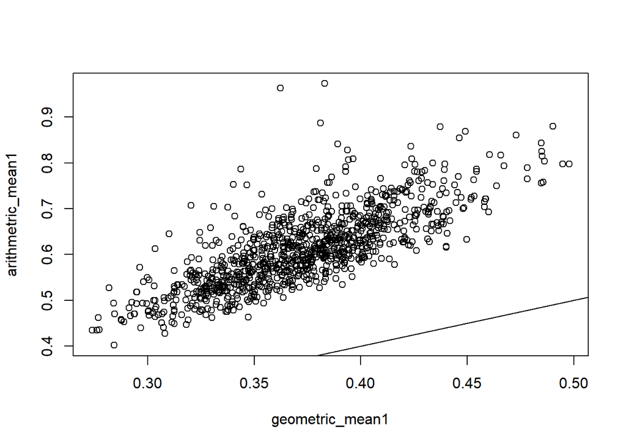

```r
x <- matrix(rlnorm(1e5, mean = -1, sd = 1), nrow = 1000, ncol = 100)
geometric_mean <- function(x){
  exp(mean(log(x)))
}
geometric_mean1 <- apply(x, 1, geometric_mean)
arithmetric_mean1 <- apply(x, 1, mean)
plot(x = geometric_mean1, y = arithmetric_mean1)
abline(0,1)
```

Generate a histogram of the difference between the arithmetic mean and the geometric mean

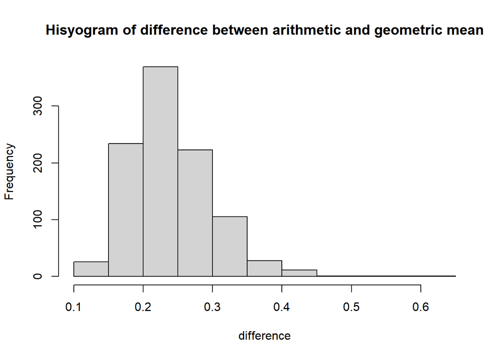

```r
difference <- arithmetric_mean1 - geometric_mean1
hist(difference, main = "Hisyogram of difference between arithmetic and geometric mean")
```

## Distribution 3

The third distribution we want to explore is the uniform distribution between 0 and 12.

Generate a figure of the PDF and CDF. Mark the mean and median in the figure.

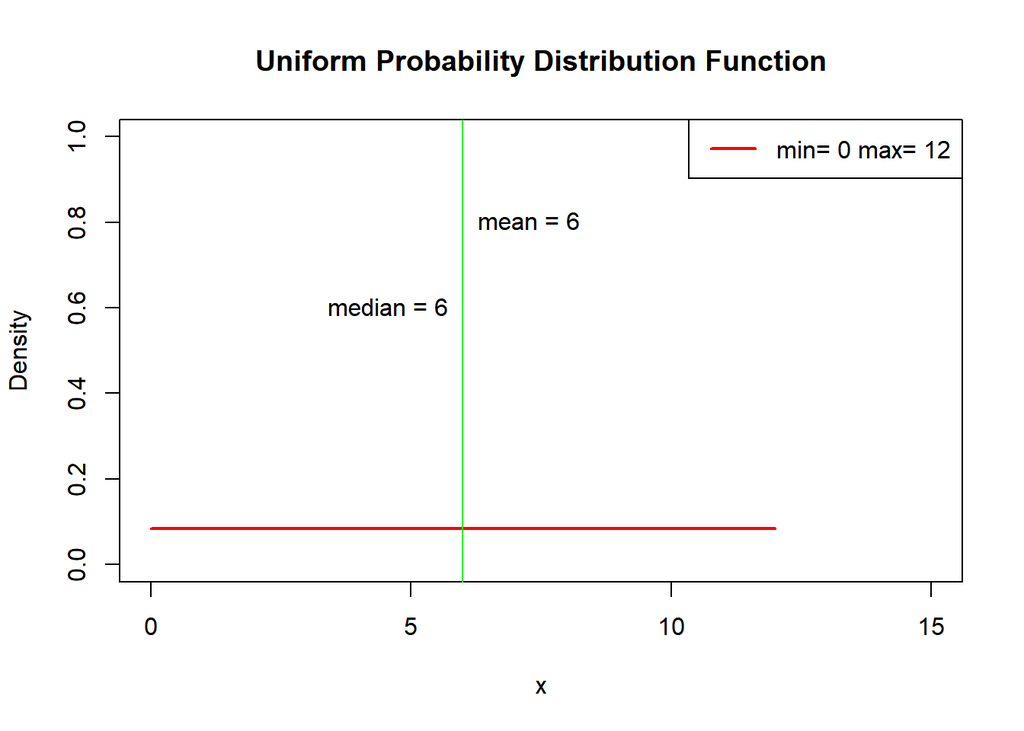

```r
# Probability distribution function
x = seq(0, 12, 0.01)
y = dunif(x, 0, 12)

plot(x, y, main="Uniform Probability Distribution Function", ylab = "Density", xlim = c(0, 15), ylim = c(0, 1), col = "red", type = "l", lwd = 2)
legend("topright", legend = paste("min=", 0, "max=", 12), lwd = 2, col = "red")
abline(v = 6, col = "blue")
text(x = 6, y = 0.8, "mean = 6", pos = 4)
abline(v = 6, col = "green")
text(x = 6, y = 0.6, "median = 6", pos = 2)
```

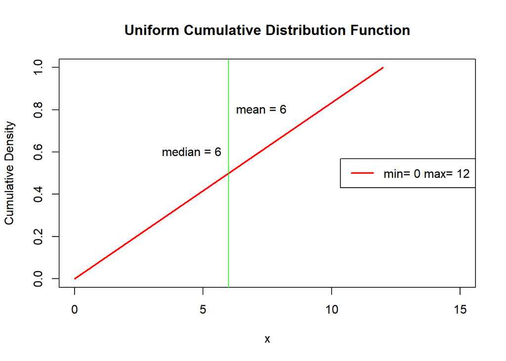

```r
# Cumulative distribution function
x = seq(0, 12, 0.01)
y = punif(x, 0, 12)

plot(x, y, main="Uniform Cumulative Distribution Function", ylab = "Cumulative Density", xlim = c(0, 15), ylim = c(0, 1), col = "red", type = "l", lwd = 2)
legend("right", legend = paste("min=", 0, "max=", 12), lwd = 2, col = "red")
abline(v = 6, col = "blue")
text(x = 6, y = 0.8, "mean = 6", pos = 4)
abline(v = 6, col = "green")
text(x = 6, y = 0.6, "median = 6", pos = 2)
```

Generate a figure of the PDF and CDF of the transformation Y = log(X) random variable. Mark the mean and median in the figure. You may use simulation or analytic methods in order find the PDF and CDF of the transformation.

I use the simulation method to find the PDF and CDF of the transformation.

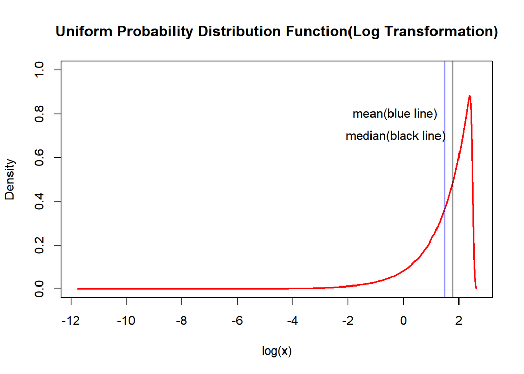

```r
# Probability distribution function
set.seed(5)
x = runif(1e6, 0, 12)
y = log(x)
plot(density(y), main = "Uniform Probability Distribution Function(Log Transformation)",  xlab = "log(x)", ylim = c(0, 1), col = "red", type = "l", lwd = 2)
abline(v = mean(y), col = "blue")
text(x = mean(y), y = 0.8, "mean(blue line)", pos = 2)
abline(v = median(y))
text(x = median(y), y = 0.7, "median(black line)", pos = 2)
```

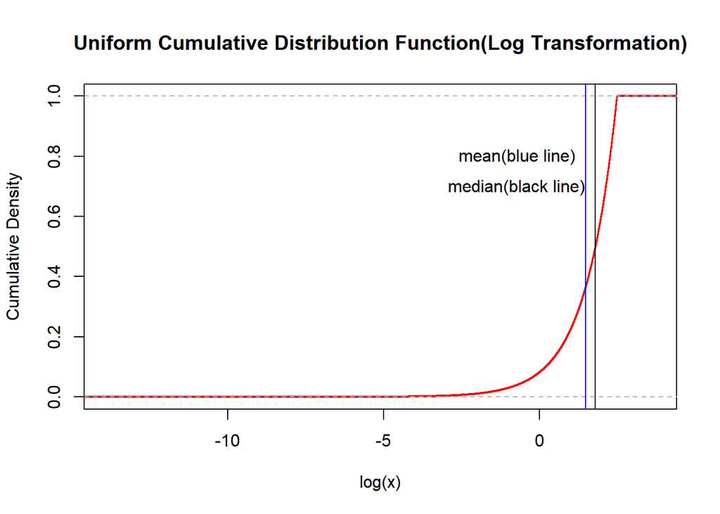

```r
# Cumulative distribution function
set.seed(6)
x = runif(1e6, 0, 12)
y = log(x)
plot(ecdf(y), main = "Uniform Cumulative Distribution Function(Log Transformation)", xlab = "log(x)", ylab = "Cumulative Density", ylim = c(0, 1), col = "red", lwd = 2)
abline(v = mean(y), col = "blue")
text(x = mean(y), y = 0.8, "mean(blue line)", pos = 2)
abline(v = median(y))
text(x = median(y), y = 0.7, "median(black line)", pos = 2)
```

Generate 1000 samples of size 100. For each sample, calculate the geometric and arithmetic mean. Generate a scatter plot of the geometic and arithmetic sample means. Add the line of identify as a reference line.

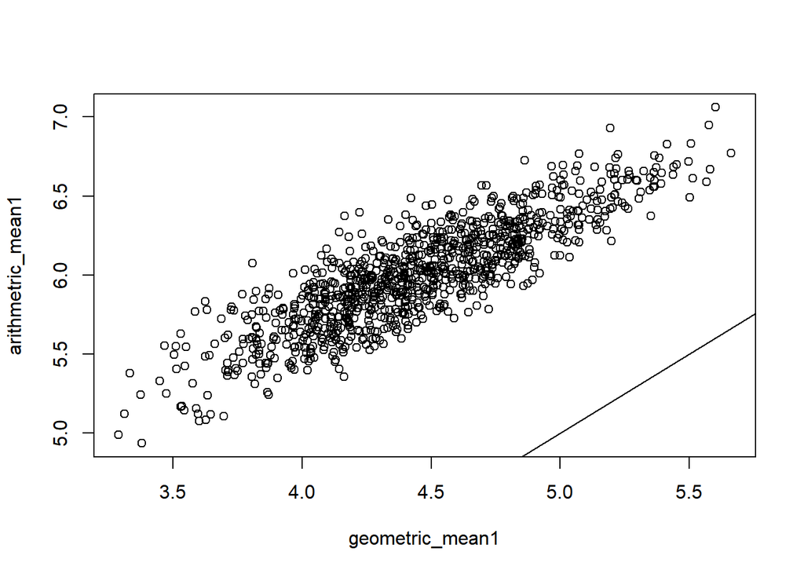

```r
x <- matrix(runif(1e5, 0, 12), nrow = 1000, ncol = 100)
geometric_mean <- function(x){
  exp(mean(log(x)))
}
geometric_mean1 <- apply(x, 1, geometric_mean)
arithmetric_mean1 <- apply(x, 1, mean)
plot(x = geometric_mean1, y = arithmetric_mean1)
abline(0,1)
```

Generate a histogram of the difference between the arithmetic mean and the geometric mean

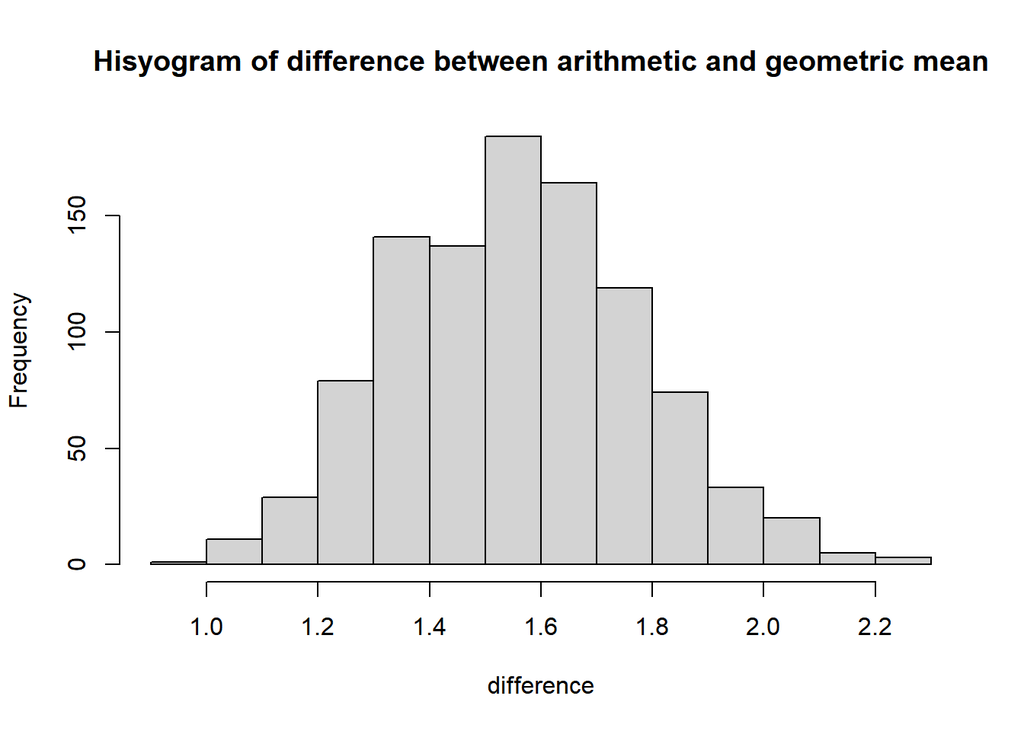

```r
difference <- arithmetric_mean1 - geometric_mean1
hist(difference, main = "Hisyogram of difference between arithmetic and geometric mean")
```

# Part 2

I will use simulation method to show this rule.

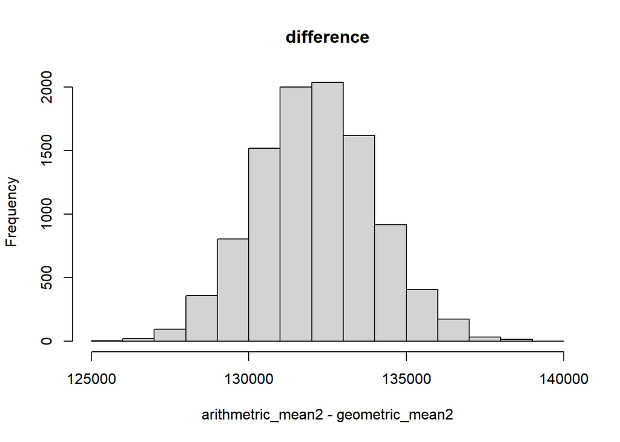

```r
# Set the random number seed.
set.seed(7)
arithmetric_mean2 <- c()
geometric_mean2 <- c()
for (i in 1:1e4) {
# Generate uniform distribution random number and calculate their arithmetric mean and geometric mean separately.
  x <- runif(1e4, 0, 1e6)
  arithmetric_mean2 <- c(arithmetric_mean2, mean(x))
  geometric_mean2 <- c(geometric_mean2, exp(mean(log(x))))
}
# Plot the histogram of the difference between arithmetric mean and geometric mean.
hist(arithmetric_mean2 - geometric_mean2, main = "difference")
```

As the above graph shows, the histogram of difference has all the values larger than 0, so we can make a conclusion that the arithmetric mean is larger than the geometric mean.

# Part 3

I will use simulation and analytic method to show that log(E(x)) is always larger than E[log(x)].

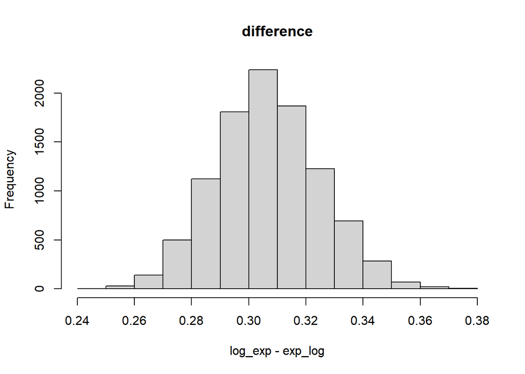

```r
set.seed(8)
log_exp <- c()
exp_log <- c()
# Set a for loop to replicate the data generate process and verify if the conclusion is correct for all cases.
for (i in 1:1e4) {
# Generate uniform distribution random number.
  x <- runif(1e3, 0, 1e6)
# Calculate the values and store them into the variables.
  log_exp <- c(log_exp, log(mean(x)))
  exp_log <- c(exp_log, mean(log(x)))
}
# Plot a histogram to see the results.
hist(log_exp - exp_log, main = "difference")
```

As the above graph shows, the histogram of difference has all the values larger than 0, so we can make a conclusion that the log(mean(x)) is larger than the mean(log(x)).

Analytic method

As we all know, we can get the following result through the plot:

$e^{x} \geq (x+1)$

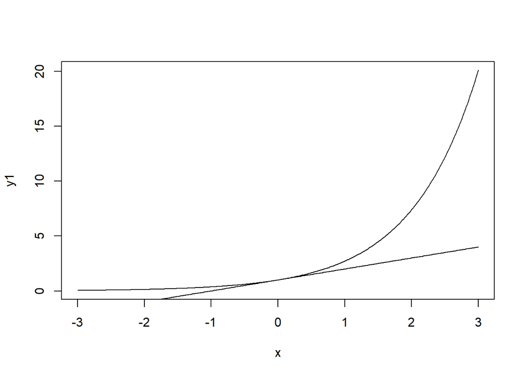

```r
x = seq(-3, 3, 0.02)
y1 = exp(x)
y2 = x + 1
plot(x, y1, type = "l")
lines(x, y2, type ="l")
```

Imagine a random variable y:

[output not shown]

Do logarithmic processing for the both sides.\